# ST2195 – Epsilon-Greedy Multi-Armed Bandit (R)

Hasan Rashed Mohamed Almadani — Student ID: stu-00104554

15/12/2025

# 1 Introduction

This report implements and analyzes the Epsilon-Greedy algorithm for the Multi-Armed Bandit problem. It aims to find the best of five advertising “arms” by balancing exploration and exploitation. Solutions for Part A (simulation), Part B (parameter analysis), and Part C (optimistic initialization) are provided, with visualizations and analysis.

## 1.1 Student Information

- **Name:** Hasan Rashed Mohamed Almadani
- **Student ID:** stu-00104554

## 1.2 1) Configuration

This section defines all the key parameters for our experiments, centralizing them for easy modification and clarity.

```r
# --- General Parameters ---
N_STEPS <- 10000 # Number of iterations
RANDOM_SEED <- 2025 # For reproducibility

# --- Bandit Parameters ---
# The true probability of success for each of the K=5 arms
TRUE_PROBS <- c(0.10, 0.50, 0.20, 0.05, 0.30)

# --- Experiment Parameters ---
# Epsilon values to test in Part B
EPSILON_VALUES <- c(0.01, 0.10, 0.50)

# Balanced epsilon for Parts A & C
BALANCED_EPSILON <- 0.10

# Optimistic Q-value for Part C
OPTIMISTIC_Q <- 5.0
```

## 1.3 2) Core Functions

Defines functions for the Epsilon-Greedy algorithm, cumulative average, and plotting. The `run_bandit` function now includes `initial_q` and returns `regrets`. A `plot_regret` function is also included.

```r
# Epsilon-Greedy Bandit implementation
run_bandit <- function(epsilon, n_steps, true_probs, initial_q = 0.0) {
  K <- length(true_probs)
  Q <- rep(initial_q, K) # Initializes Q-values
  N_arm <- rep(0L, K)
  rewards <- numeric(n_steps)
  choices <- integer(n_steps)
  regrets <- numeric(n_steps) # Stores instantaneous regrets

  p_opt <- max(true_probs) # The true probability of the optimal arm

  for (i in seq_len(n_steps)) {
    # Explore vs Exploit
    if (runif(1) < epsilon) {
      arm <- sample.int(K, 1)
    } else {
      arm <- which.max(Q)
    }

    # Bernoulli reward
    reward <- if (runif(1) < true_probs[arm]) 1.0 else 0.0

    # Calculates instantaneous regrets
    regrets[i] <- p_opt - true_probs[arm]

    # Update incremental mean
    N_arm[arm] <- N_arm[arm] + 1L
    Q[arm] <- Q[arm] + (reward - Q[arm]) / N_arm[arm]

    rewards[i] <- reward
    choices[i] <- arm
  }

  list(Q = Q, N_arm = N_arm, rewards = rewards, choices = choices, regrets = regrets)
}

cumulative_average <- function(x) {
  cumsum(x) / seq_along(x)
}

plot_cumavg <- function(curves, labels, p_opt = NULL,
                        title = "Cumulative Average Reward",
                        colors = NULL) {
  if (is.null(colors)) {
    colors <- c("blue", "green", "red", "purple", "brown")
  }
  n <- length(curves)
  if (n == 0) stop("curves cannot be empty")

  plot(curves[[1]], type = "l", col = colors[1], lwd = 2,
       xlab = "Iteration", ylab = "Cumulative average reward", main = title,
       ylim = c(min(unlist(curves), na.rm = TRUE), max(unlist(curves), na.rm = TRUE, p_opt)))
  if (n > 1) {
    for (j in 2:n) lines(curves[[j]], col = colors[j], lwd = 2)
  }
  if (!is.null(p_opt)) {
    abline(h = p_opt, col = "black", lty = 2, lwd = 2)
    legend("bottomright", legend = c(labels, sprintf("Theoretical max = %.2f", p_opt)),
           col = c(colors[seq_len(n)], "black"), lty = c(rep(1, n), 2), lwd = 2, bty = "n")
  } else {
    legend("bottomright", legend = labels, col = colors[seq_len(n)], lty = 1, lwd = 2, bty = "n")
  }
}

plot_regret <- function(curves, labels, title = "Cumulative Regret", colors = NULL) {
  if (is.null(colors)) {
    colors <- c("blue", "green", "red", "purple", "brown")
  }
  n <- length(curves)
  if (n == 0) stop("curves cannot be empty")

  plot(curves[[1]], type = "l", col = colors[1], lwd = 2,
       xlab = "Iteration", ylab = "Cumulative Regret", main = title,
       ylim = c(0, max(unlist(curves), na.rm = TRUE)))
  if (n > 1) {
    for (j in 2:n) lines(curves[[j]], col = colors[j], lwd = 2)
  }
  legend("topleft", legend = labels, col = colors[seq_len(n)], lty = 1, lwd = 2, bty = "n")
}
```

## 1.4 3) Part A — Single run with ε = 0.10

Simulation runs for `N_STEPS` iterations with `BALANCED_EPSILON`. Both cumulative average reward and regret are plotted.

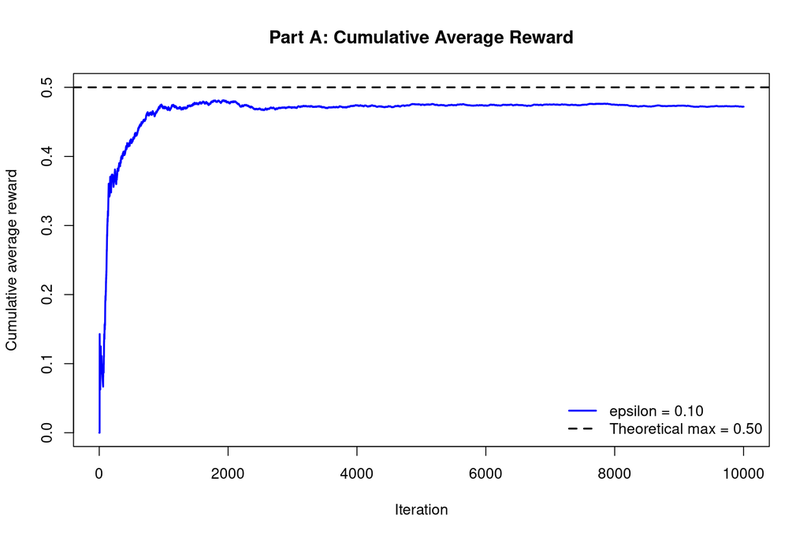

```r
res_A <- run_bandit(BALANCED_EPSILON, N_STEPS, TRUE_PROBS)
cumavg_A <- cumulative_average(res_A$rewards)
cum_regret_A <- cumsum(res_A$regrets)

p_opt <- max(TRUE_PROBS)

# Plot the Cumulative Average Reward
plot_cumavg(list(cumavg_A), labels = list(sprintf("epsilon = %.2f", BALANCED_EPSILON)),
            p_opt = p_opt,
            title = "Part A: Cumulative Average Reward")
```

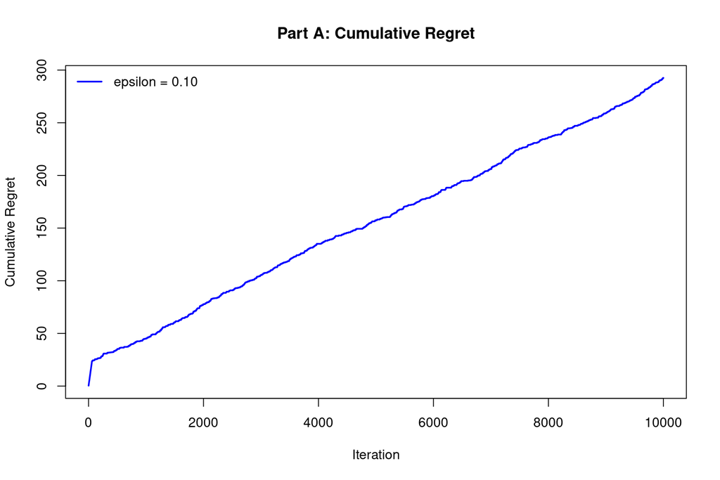

```r
# Plot the Cumulative Regret
plot_regret(list(cum_regret_A), labels = list(sprintf("epsilon = %.2f", BALANCED_EPSILON)),
            title = "Part A: Cumulative Regret")
```

```r
cat("\nFinal estimates Q:\n"); print(round(res_A$Q, 3))
```

```
##
## Final estimates Q:
```

```
## [1] 0.104 0.501 0.221 0.059 0.286
```

```r
cat("Arm pulls:\n"); print(res_A$N_arm)
```

```
## Arm pulls:
```

```
## [1]  249 9144  208  203  196
```

```r
cat("Optimal arm index:", which.max(TRUE_PROBS), "with p=", p_opt, "\n")
```

```
## Optimal arm index: 2 with p= 0.5
```

## 1.5 4) Part B — Parameter Analysis

Compares algorithm performance across `EPSILON_VALUES` to study the exploration-exploitation trade-off.

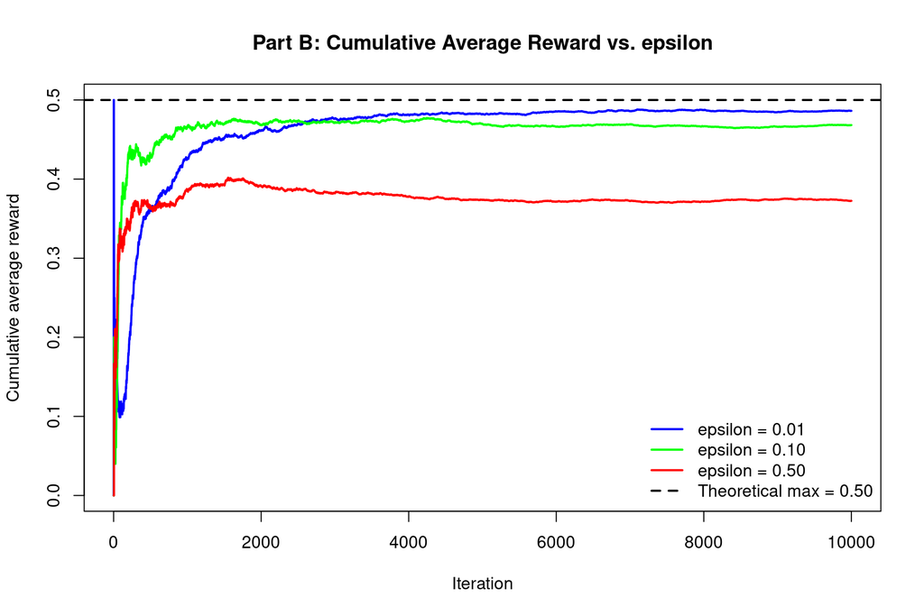

```r
results <- list()
cumavg_curves <- list(); cumavg_labels <- list()
regret_curves <- list(); regret_labels <- list()

for (eps in EPSILON_VALUES) {
  res <- run_bandit(eps, N_STEPS, TRUE_PROBS)
  results[[as.character(eps)]] <- res # Store full results for metrics calculation

  cumavg_curves[[length(cumavg_curves) + 1]] <- cumulative_average(res$rewards)
  cumavg_labels[[length(cumavg_labels) + 1]] <- sprintf("epsilon = %.2f", eps)

  regret_curves[[length(regret_curves) + 1]] <- cumsum(res$regrets)
  regret_labels[[length(regret_labels) + 1]] <- sprintf("epsilon = %.2f", eps)
}

p_opt <- max(TRUE_PROBS)

# Plot overlay for Cumulative Average Reward
plot_cumavg(cumavg_curves, cumavg_labels, p_opt = p_opt,
            title = "Part B: Cumulative Average Reward vs. epsilon")
```

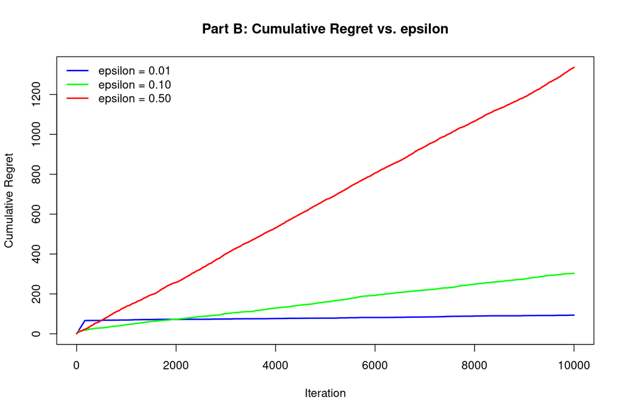

```r
# Plot overlay for Cumulative Regret
plot_regret(regret_curves, regret_labels, title = "Part B: Cumulative Regret vs. epsilon")
```

```r
# ---
# Metrics
# ---
threshold <- 0.95 * p_opt
TAIL <- 1000
mean_p <- mean(TRUE_PROBS)

cat("Convergence (first step to reach >= 95% of optimal):\n")
```

```
## Convergence (first step to reach >= 95% of optimal):
```

```r
for (eps in EPSILON_VALUES) {
  y <- cumulative_average(results[[as.character(eps)]]$rewards)
  idx <- which(y >= threshold)[1]
  val <- if (is.na(idx)) "never" else as.character(idx)
  cat(sprintf("  epsilon=%.2f: %s\n", eps, val))
}
```

```
##   epsilon=0.01: 2
##   epsilon=0.10: 1606
##   epsilon=0.50: never
```

```r
cat("\nStability (variance of last 1000 points; smaller is stabler):\n")
```

```
##
## Stability (variance of last 1000 points; smaller is stabler):
```

```r
for (eps in EPSILON_VALUES) {
  y <- cumulative_average(results[[as.character(eps)]]$rewards)
  tail_y <- tail(y, TAIL)
  cat(sprintf("  epsilon=%.2f: %.6f\n", eps, var(tail_y)))
}
```

```
##   epsilon=0.01: 0.000000
##   epsilon=0.10: 0.000001
##   epsilon=0.50: 0.000000
```

```r
cat("\nAsymptotic expected average reward (approx):\n")
```

```
##
## Asymptotic expected average reward (approx):
```

```r
for (eps in EPSILON_VALUES) {
  asym <- (1 - eps) * p_opt + eps * mean_p
  cat(sprintf("  epsilon=%.2f: %.3f\n", eps, asym))
}
```

```
##   epsilon=0.01: 0.497
##   epsilon=0.10: 0.473
##   epsilon=0.50: 0.365
```

## 1.6 5) Part C — Optimistic Initial Values

Explores **Optimistic Initial Values** for forced exploration. Q-values are set to `OPTIMISTIC_Q` (high), compelling the algorithm to explore all arms. Compared to standard initialization.

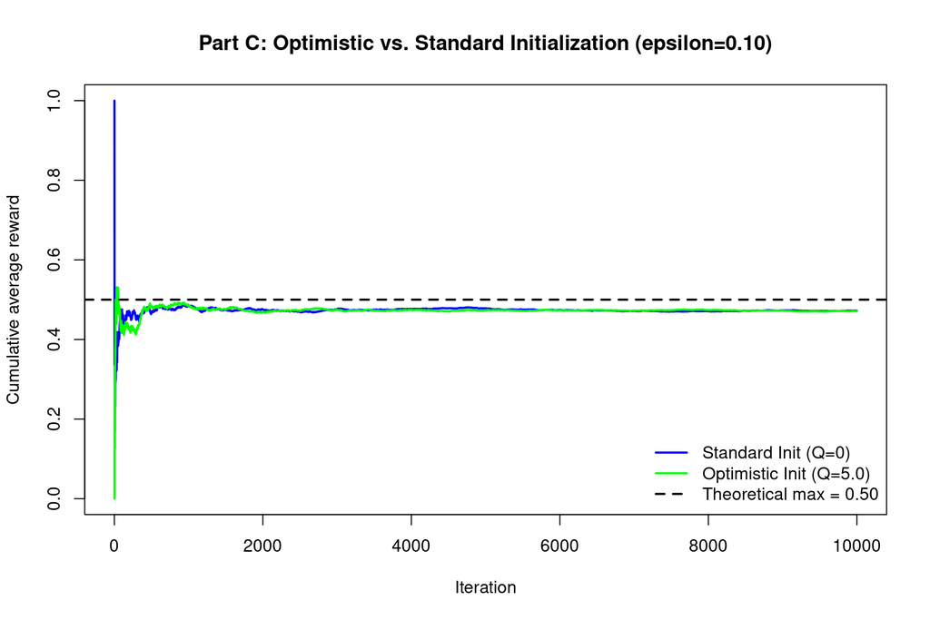

```r
# Standard (zero) initialization
res_std <- run_bandit(BALANCED_EPSILON, N_STEPS, TRUE_PROBS, initial_q = 0.0)
cumavg_std <- cumulative_average(res_std$rewards)
cum_regret_std <- cumsum(res_std$regrets)

# Optimistic initialization
res_opt <- run_bandit(BALANCED_EPSILON, N_STEPS, TRUE_PROBS, initial_q = OPTIMISTIC_Q)
cumavg_opt <- cumulative_average(res_opt$rewards)
cum_regret_opt <- cumsum(res_opt$regrets)

p_opt <- max(TRUE_PROBS)

# Plot Cumulative Average Reward
plot_cumavg(list(cumavg_std, cumavg_opt),
            labels = list("Standard Init (Q=0)", sprintf("Optimistic Init (Q=%.1f)", OPTIMISTIC_Q)),
            p_opt = p_opt,
            title = sprintf("Part C: Optimistic vs. Standard Initialization (epsilon=%.2f)", BALANCED_EPSILON))
```

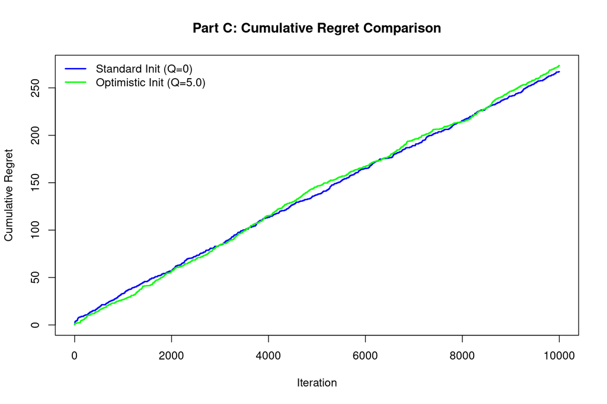

```r
# Plot Cumulative Regret
plot_regret(list(cum_regret_std, cum_regret_opt),
            labels = list("Standard Init (Q=0)", sprintf("Optimistic Init (Q=%.1f)", OPTIMISTIC_Q)),
            title = "Part C: Cumulative Regret Comparison")
```

## 1.7 6) Additional Analysis: Arm Pull Distribution

Visualizes arm pull distribution for standard vs. optimistic agents to show exploration strategy.

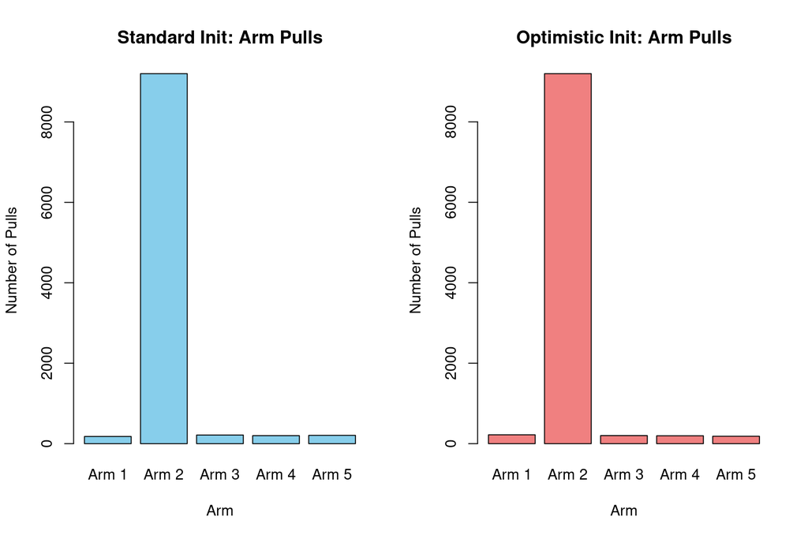

```r
# Prepare plotting data
arm_names <- paste("Arm", 1:length(TRUE_PROBS))
counts_df <- data.frame(
  Arm = rep(arm_names, 2),
  Strategy = c(rep("Standard Init", length(TRUE_PROBS)), rep("Optimistic Init", length(TRUE_PROBS))),
  Pulls = c(res_std$N_arm, res_opt$N_arm)
)

# Base R barplot
par(mfrow = c(1, 2), mar = c(5, 4, 4, 2) + 0.1) # Set 2 plots side-by-side
barplot(res_std$N_arm, names.arg = arm_names, main = "Standard Init: Arm Pulls",
        ylab = "Number of Pulls", xlab = "Arm", col = "skyblue")
barplot(res_opt$N_arm, names.arg = arm_names, main = "Optimistic Init: Arm Pulls",
        ylab = "Number of Pulls", xlab = "Arm", col = "lightcoral")
```

```r
par(mfrow = c(1, 1)) # Reset layout
```